# Entrega final

   La técnica realizada en la investigación surgió como alternativa ante la inviabilidad de la aplicación del Análisis Factorial, dado que, pese a obtener un KMO de 0.85, al redimensionar la data en los tres factores sugeridos, la insuficiencia de la misma impidió continuar con el procedimiento. En ese sentido, se ejecutaron las tres técnicas de clusterización estudiadas, siendo la más óptima la realizada vía el algoritmo DIANA.
- Proceso de clusterización

```r
#Tipificando la distribución de los datos
data=BD[complete.cases(BD),]
library(BBmisc)
```

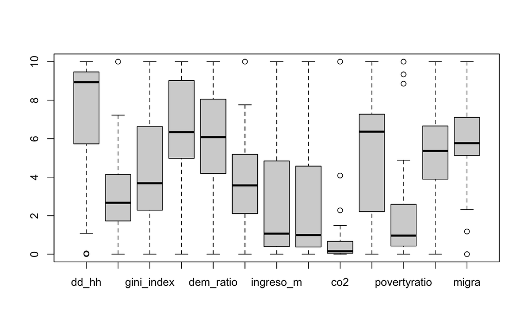

```r
boxplot(normalize(data[,c(3:15)],method='range',range=c(0,10)))
```

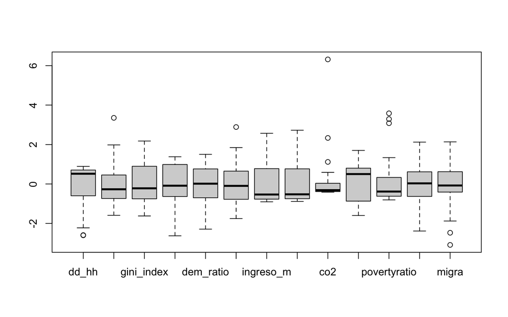

```r
boxplot(normalize(data[,c(3:15)],method='standardize'))
```

```r
#Obteniendo la cantidad de clusters
subclus=data[,c(3:15)]
library(factoextra)
```

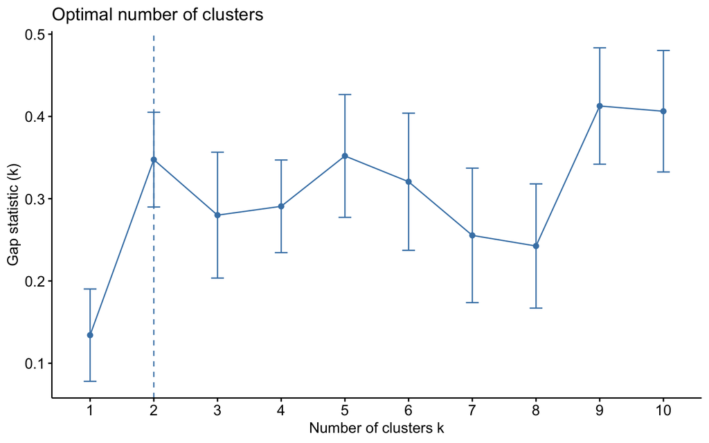

```r
fviz_nbclust(subclus, hcut,diss=g.dist,method = "gap_stat",k.max = 10,verbose = F,hc_func = "diana")
```

```r
#Clusterización vía DIANA
library(cluster)
library(kableExtra)
g.dist = daisy(subclus, metric="gower")
res.diana=hcut(g.dist, k = 2,hc_func='diana')
subclus$diana=res.diana$cluster
head(subclus,15)%>%kbl%>%kable_styling()
```

|  | dd_hh | unemp_rate | gini_index | des_huma | dem_ratio | paci | ingreso_m | pbi_per | co2 | fragil_ind_score | povertyratio | econ_free | migra | diana |
| --- | --- | --- | --- | --- | --- | --- | --- | --- | --- | --- | --- | --- | --- | --- |
| 2 | 0.878 | 11.4 | 34.76 | 0.796 | 6.41 | 1.761 | 431 | 6493 | 4.591 | 58.9 | 0.3 | 65.3 | -3.22 | 1 |
| 8 | 0.884 | 15.3 | 29.51 | 0.759 | 5.63 | 1.992 | 342 | 4967 | 6.770 | 66.7 | 0.4 | 65.1 | -5.28 | 1 |
| 9 | 0.920 | 5.1 | 34.34 | 0.951 | 8.71 | 1.565 | 4028 | 60443 | 367.907 | 19.7 | 2.2 | 74.8 | 6.39 | 2 |
| 17 | 0.954 | 6.3 | 27.10 | 0.937 | 7.64 | 1.526 | 3558 | 51247 | 95.924 | 28.6 | 0.8 | 67.1 | 4.18 | 2 |
| 21 | 0.819 | 6.9 | 44.76 | 0.692 | 4.51 | 1.989 | 232 | 3345 | 22.428 | 72.9 | 6.6 | 43.4 | -0.96 | 1 |
| 24 | 0.633 | 11.1 | 49.71 | 0.754 | 6.78 | 2.465 | 545 | 7507 | 489.858 | 71.8 | 6.1 | 53.5 | -0.19 | 1 |
| 35 | 0.909 | 8.9 | 50.47 | 0.855 | 8.22 | 1.840 | 1041 | 16265 | 85.703 | 38.9 | 1.0 | 71.1 | 0.32 | 2 |
| 37 | 0.639 | 13.8 | 54.01 | 0.752 | 6.72 | 2.729 | 436 | 6104 | 77.570 | 75.7 | 5.9 | 63.1 | -1.85 | 1 |
| 41 | 0.947 | 13.7 | 48.84 | 0.809 | 8.29 | 1.732 | 867 | 12472 | 8.091 | 42.0 | 2.3 | 66.5 | 0.76 | 2 |
| 47 | 0.952 | 5.1 | 26.44 | 0.948 | 9.28 | 1.296 | 4812 | 68008 | 27.280 | 19.5 | 0.9 | 77.6 | 2.71 | 2 |
| 50 | 0.895 | 7.4 | 40.33 | 0.767 | 6.39 | 1.990 | 571 | 8477 | 27.727 | 66.2 | 2.9 | 62.6 | -2.66 | 1 |
| 51 | 0.893 | 4.7 | 46.35 | 0.740 | 5.69 | 1.988 | 420 | 5965 | 41.141 | 71.2 | 6.9 | 55.0 | 0.00 | 1 |
| 52 | 0.203 | 7.3 | 35.42 | 0.731 | 2.93 | 2.242 | 236 | 3699 | 259.321 | 88.4 | 3.5 | 49.6 | -0.29 | 1 |
| 53 | 0.632 | 6.3 | 42.12 | 0.675 | 5.06 | 2.231 | 300 | 4551 | 8.176 | 69.8 | 4.4 | 56.0 | -7.01 | 1 |
| 60 | 0.953 | 7.6 | 27.78 | 0.940 | 9.29 | 1.439 | 3770 | 53655 | 38.992 | 16.9 | 1.0 | 77.1 | 2.25 | 2 |

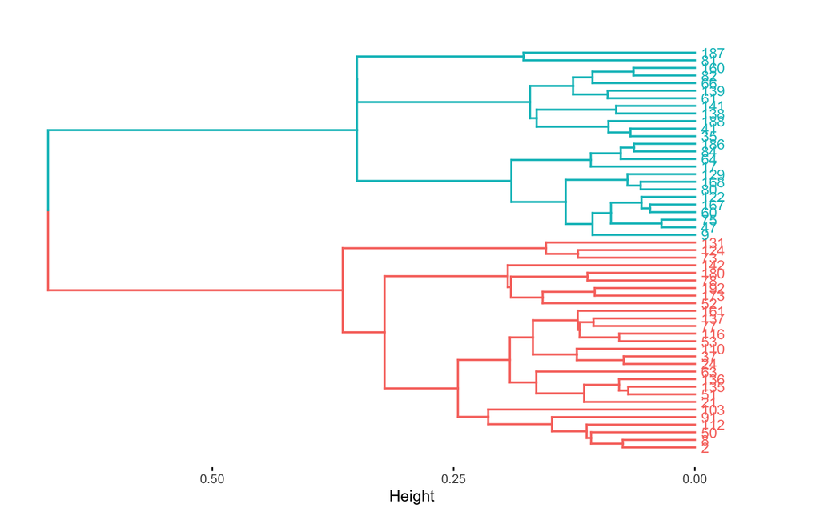

```r
#Observando el proceso en el dendograma
fviz_dend(res.diana, cex = 0.7, horiz = T, main = "")
```

```r
#Obteniendo los países mal clusterizados
silDIANA=data.frame(res.diana$silinfo$widths)
silDIANA$country=row.names(silDIANA)
poorDIANA=silDIANA[silDIANA$sil_width<0,'country']%>%sort()
poorDIANA
```

```
## character(0)
```

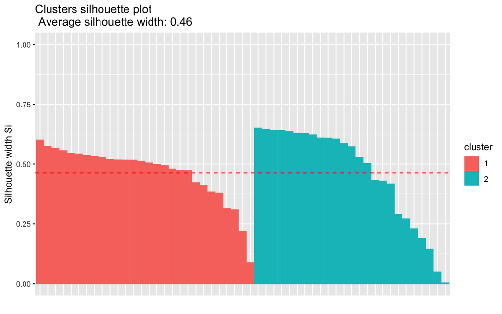

```r
#Observando gráficamente los países mal clusterizados
fviz_silhouette(res.diana,print.summary = F)
```

```r
#Calulando el promedio de cada cluster
subclus$diana=res.diana$cluster
aggregate(.~ diana, data=subclus,mean)
```

```
##   diana     dd_hh unemp_rate gini_index  des_huma dem_ratio    paci ingreso_m
## 1     1 0.6328571   8.289286   41.74429 0.7358929  5.151786 2.20225  379.3929
## 2     2 0.9242000   6.908000   33.84880 0.9101200  8.430400 1.61796 3227.5200
##     pbi_per      co2 fragil_ind_score povertyratio econ_free     migra
## 1  5535.786 231.4463         73.60714        4.775  58.08214 -1.568571
## 2 47789.280 366.9952         32.73200        1.328  71.06800  2.140800
```

- Resultados del proceso de clusterización

  Tras ejecutar los 2 factores sugeridos, resalta la no obtención de países mal clusterizados, lo que posiciona a esta técnica como la mejor en comparación a las demaaás técnicas realizadas, en las que los resultados no son concluyentes como en este caso.